# Cancer Incidence Projections Under Standard and Intended-Effect Trial Designs

Kemal Caglar Gogebakan

2026-03-20

# Scenario

This section defines the trial design, test performance, and number of participants in each arm.  
Users can change these inputs and rerun the file to explore alternative designs.

| Parameter | Value |
| --- | --- |
| Cancer type | lung |
| OMST (years) | 3.5 |
| LMST (years) | 1 |
| Early-stage sensitivity | 20% |
| Late-stage sensitivity | 95% |
| Screening interval | Annual |
| Number of screens | 10 |
| Follow-up years | 1 |
| Starting age | 66 |
| Number of participants (Control arm) | 1e+05 |
| Number of participants (Screen arm) | 1e+05 |

# Run Main Projection Function

This chunk runs the main projection function once and stores all trial results for: - both designs (`standard`, `IE`) - both arms (`control`, `screen`) - all stages (`early`, `late`, `overall`) - stage shift

# User Output Selection

The tables and figures below are generated for one selected output format.  
Users can rerun the file with different settings to obtain alternative yearly or cumulative results, and incidence or count outputs.

Selected output settings

| Setting | Value |
| --- | --- |
| Yearly or Cumulative | cumulative |
| Outcome measure | count |
| Show early-stage results | Yes |
| Show overall results | Yes |

# Standard Trial Design Projections

This section presents results under the standard trial design.  
The first table always shows late-stage results and stage shift.  
If selected above, separate early-stage and overall tables and figures are also shown.

## Tables for the Standard Trial Design

Cumulative Late-Stage Number of Cancers and Cumulative Stage Shift under Standard Trial Design

| Time since randomization | Age at start of interval | Age at end of interval | Period | Control arm | Screen-detected | Interval-detected | Total screen arm | Stage shift (%) |
| --- | --- | --- | --- | --- | --- | --- | --- | --- |
| 1 | 66 | 67 | screen | 107 | 98 | 38 | 136 | -27 |
| 2 | 67 | 68 | screen | 223 | 159 | 74 | 232 | -4 |
| 3 | 68 | 69 | screen | 348 | 217 | 109 | 327 | 6 |
| 4 | 69 | 70 | screen | 483 | 277 | 146 | 423 | 12 |
| 5 | 70 | 71 | screen | 628 | 338 | 185 | 523 | 17 |
| 6 | 71 | 72 | screen | 784 | 403 | 226 | 629 | 20 |
| 7 | 72 | 73 | screen | 950 | 471 | 269 | 741 | 22 |
| 8 | 73 | 74 | screen | 1127 | 544 | 315 | 859 | 24 |
| 9 | 74 | 75 | screen | 1317 | 620 | 363 | 984 | 25 |
| 10 | 75 | 76 | screen | 1518 | 702 | 415 | 1116 | 26 |

Cumulative Early-Stage Number of Cancers under Standard Trial Design

| Time since randomization | Age at start of interval | Age at end of interval | Period | Control arm | Screen-detected | Interval-detected | Total screen arm |
| --- | --- | --- | --- | --- | --- | --- | --- |
| 1 | 66 | 67 | screen | 47 | 88 | 40 | 127 |
| 2 | 67 | 68 | screen | 98 | 170 | 78 | 248 |
| 3 | 68 | 69 | screen | 153 | 251 | 117 | 368 |
| 4 | 69 | 70 | screen | 213 | 335 | 157 | 493 |
| 5 | 70 | 71 | screen | 276 | 423 | 200 | 622 |
| 6 | 71 | 72 | screen | 344 | 515 | 245 | 759 |
| 7 | 72 | 73 | screen | 416 | 612 | 292 | 904 |
| 8 | 73 | 74 | screen | 493 | 716 | 342 | 1058 |
| 9 | 74 | 75 | screen | 576 | 825 | 395 | 1221 |
| 10 | 75 | 76 | screen | 663 | 941 | 452 | 1392 |

Cumulative Overall Number of Cancers under Standard Trial Design

| Time since randomization | Age at start of interval | Age at end of interval | Period | Control arm | Screen-detected | Interval-detected | Total screen arm |
| --- | --- | --- | --- | --- | --- | --- | --- |
| 1 | 66 | 67 | screen | 155 | 185 | 78 | 263 |
| 2 | 67 | 68 | screen | 322 | 328 | 152 | 480 |
| 3 | 68 | 69 | screen | 502 | 469 | 226 | 695 |
| 4 | 69 | 70 | screen | 696 | 612 | 304 | 915 |
| 5 | 70 | 71 | screen | 904 | 761 | 385 | 1146 |
| 6 | 71 | 72 | screen | 1127 | 918 | 471 | 1388 |
| 7 | 72 | 73 | screen | 1366 | 1084 | 561 | 1645 |
| 8 | 73 | 74 | screen | 1621 | 1259 | 657 | 1917 |
| 9 | 74 | 75 | screen | 1892 | 1446 | 759 | 2204 |
| 10 | 75 | 76 | screen | 2181 | 1642 | 866 | 2509 |

## Figures for the Standard Trial Design

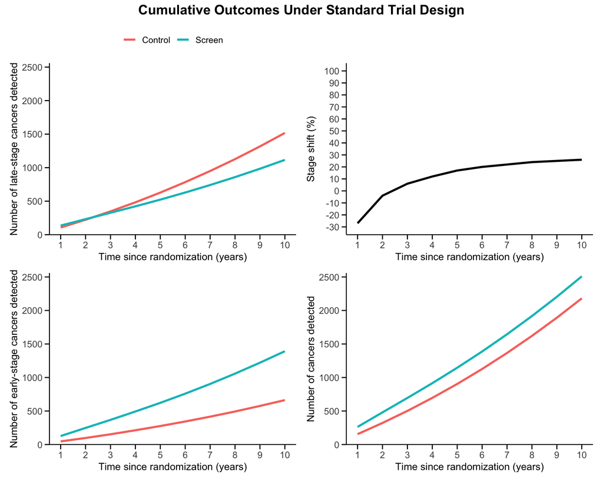

# Intended-Effect Trial Design Projections

This section presents parallel results under the intended-effect design.  
A positivity-rate table is shown first because intended-effect results are conditional on ever-positive status.

## Positivity rate

Positivity rate at the end of the screening period

| Measure | Value |
| --- | --- |
| Early-stage screen-positive fraction | 0.9% |
| Late-stage screen-positive fraction | 0.7% |
| Overall screen-positive fraction | 1.6% |

## Tables for the Intended Effect Trial Design

Cumulative Late-Stage Number of Cancers and Cumulative Stage Shift under Intended-Effect Trial Design

| Time since randomization | Age at start of interval | Age at end of interval | Period | Control arm | Screen-detected | Interval-detected | Total screen arm | Stage shift (%) |
| --- | --- | --- | --- | --- | --- | --- | --- | --- |
| 1 | 66 | 67 | screen | 69 | 98 | 0 | 98 | -42 |
| 2 | 67 | 68 | screen | 149 | 159 | 0 | 159 | -6 |
| 3 | 68 | 69 | screen | 238 | 217 | 0 | 217 | 9 |
| 4 | 69 | 70 | screen | 336 | 277 | 0 | 277 | 18 |
| 5 | 70 | 71 | screen | 441 | 338 | 0 | 338 | 23 |
| 6 | 71 | 72 | screen | 554 | 403 | 0 | 403 | 27 |
| 7 | 72 | 73 | screen | 675 | 471 | 0 | 471 | 30 |
| 8 | 73 | 74 | screen | 805 | 544 | 0 | 544 | 32 |
| 9 | 74 | 75 | screen | 942 | 620 | 0 | 620 | 34 |
| 10 | 75 | 76 | screen | 1089 | 702 | 0 | 702 | 36 |

Cumulative Early-Stage Number of Cancers under Intended-Effect Trial Design

| Time since randomization | Age at start of interval | Age at end of interval | Period | Control arm | Screen-detected | Interval-detected | Total screen arm |
| --- | --- | --- | --- | --- | --- | --- | --- |
| 1 | 66 | 67 | screen | 8 | 88 | 0 | 88 |
| 2 | 67 | 68 | screen | 20 | 170 | 0 | 170 |
| 3 | 68 | 69 | screen | 36 | 251 | 0 | 251 |
| 4 | 69 | 70 | screen | 55 | 335 | 0 | 335 |
| 5 | 70 | 71 | screen | 75 | 423 | 0 | 423 |
| 6 | 71 | 72 | screen | 97 | 515 | 0 | 515 |
| 7 | 72 | 73 | screen | 122 | 612 | 0 | 612 |
| 8 | 73 | 74 | screen | 148 | 716 | 0 | 716 |
| 9 | 74 | 75 | screen | 175 | 825 | 0 | 825 |
| 10 | 75 | 76 | screen | 205 | 941 | 0 | 941 |

[output not shown]

## Figures for the Intended Effect Design

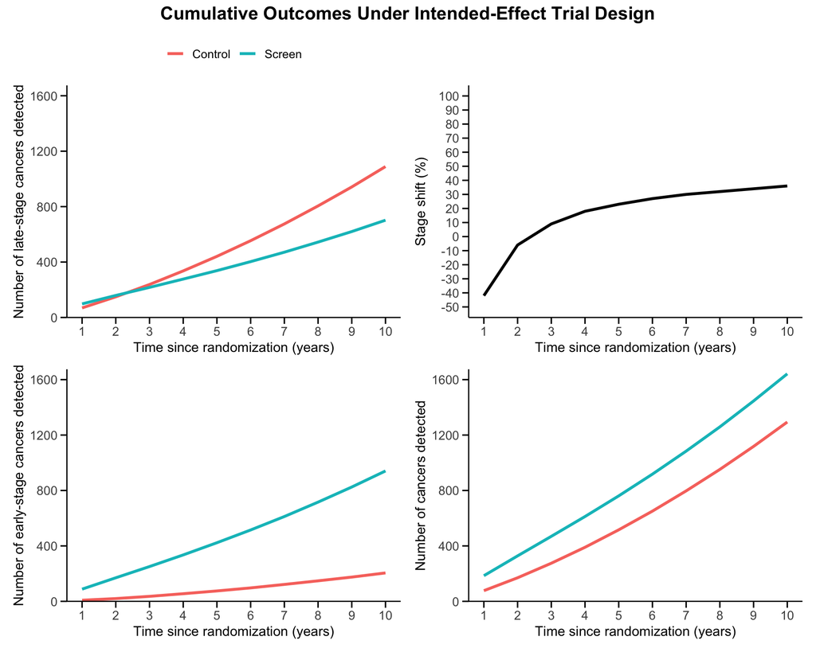

# Per-arm / total sample size and achieved power

This section computes: - the required total sample size for the target power - the achieved power under the current sample sizes - for both the standard and intended-effect designs

Power calculation inputs

| Parameter | Value |
| --- | --- |
| Significance level (alpha) | 0.025 |
| Target power (%) | 80 |
| Number in control arm | 1e+05 |
| Number in screen arm | 1e+05 |
| Total sample size | 2e+05 |
| Allocation ratio (R = n_control / n_screen) | 1 |

Required total sample size and achieved power under each trial design (current total N = 2e+05)

| Trial_Design | Cumulative_incidence_control_arm | Cumulative_incidence_screen_arm | Required_total_sample_size | Power_under_current_design |
| --- | --- | --- | --- | --- |
| Standard | 0.0151830 | 0.0111636 | 25263 | 100 |
| Intended-Effect | 0.6629602 | 0.4272187 | 8529 | 100 |

Current allocation, positivity rate, and sample-size ratio

| Measure | Value |
| --- | --- |
| Number of participants in control arm | 1e+05 |
| Number of participants in screen arm | 1e+05 |
| Number of participants in the trial | 2e+05 |
| Allocation ratio R = n_control / n_screen | 1 |
| Positivity rate | 0.0164 |
| Required N ratio: IE / Standard | 0.34 |

# Interpretation

- Standard design results are population-level projections.
- Intended-effect design results are conditional on ever-positive individuals.
- To explore alternative projections or sample-size requirements, users can change:
  - number of screens
  - screening interval
  - follow-up duration
  - test sensitivities